# Statistical debugging of `sceptre` part 2

Tim

2022-09-06

We seek to answer four outstanding questions in this writeup:

1. Is the Fisher exact test calibrated on the negative control data? If so, can we draw conclusions about why the other methods might be miscalibrated?
2. Why does the Fisher exact test yield a large fraction of p-values equal to exactly 1?
3. Why are the methods poorly calibrated on the Schraivogel perturb-seq data?
4. What QC threshold should we be using? If we adopt a more stringent QC threshold, do the methods remain miscalibrated?

# Question 1: Is the Fisher exact test calibrated on the negative control data?

I applied Fisher’s exact test to the negative control data within the framework of the undercover pipeline (using group size = 1). Below, I plot the resulting *p*-values on a negative log 10 transformed scale.

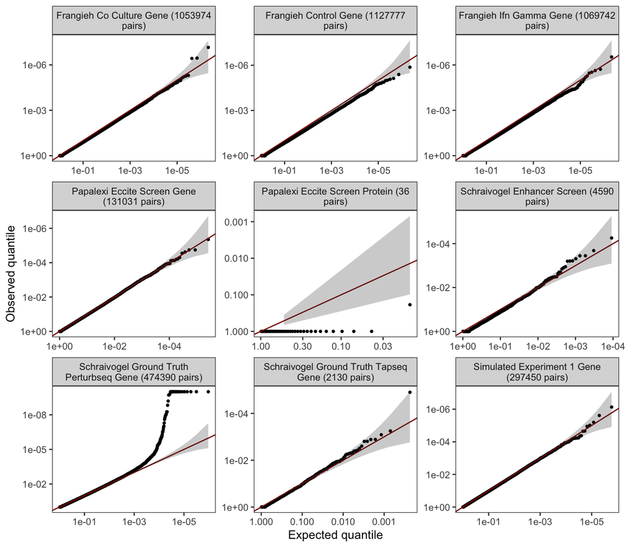

Amazingly, the *p*-values are calibrated far into the tail of the distribution on all of the datasets (with the exception of the Papalexi protein data and the Schraivogel perturb-seq data; more on those below). Hence, confounding likely is negligible (because if confounding were non-negligible, then the Fisher exact test, which is a test of *marginal* rather than *conditional* independence, would be miscalibrated). Seurat DE and SCEPTRE (not depicted) also are nonparametric tests of marginal independence. Both of these methods are miscalibrated on the negative control data. The miscalibration of Seurat DE and SCEPTRE likely is not the result of confounding; rather, the assumptions that Seurat DE and SCEPTRE make about the null distribution of the test statistic (i.e., that the test statistic is Gaussian distributed or skew-normal distributed) likely are wrong for some fraction of the pairs.

Next, I plot the negative control *p*-values on an untransformed scale.

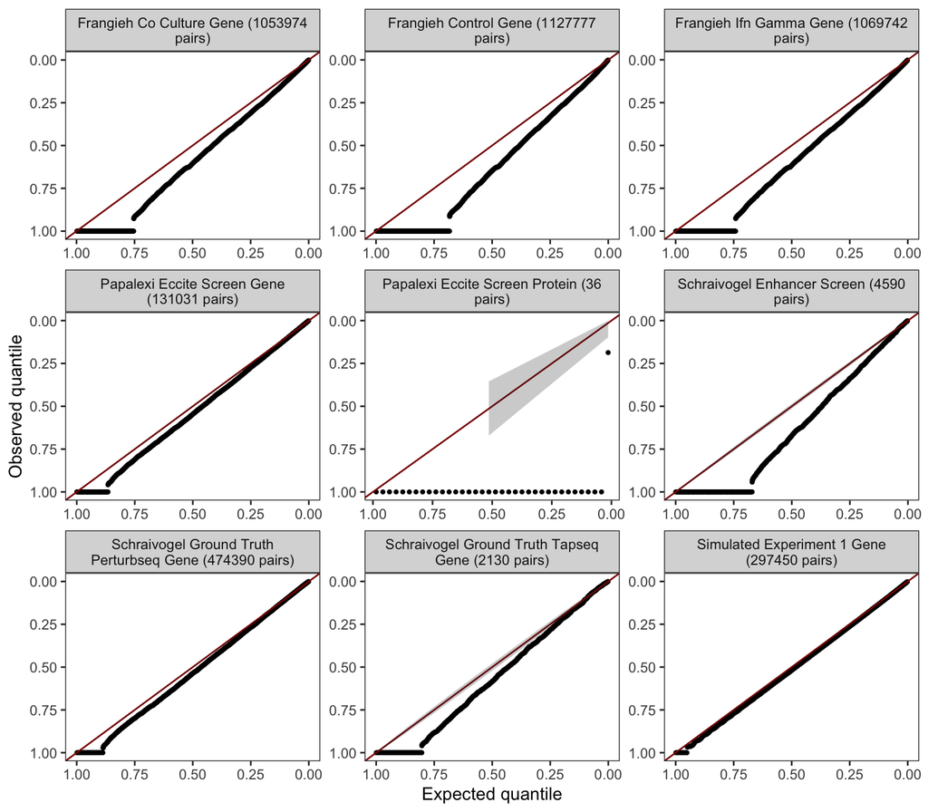

Finally, I applied Fisher’s exact test to the (grouped) positive control data. The number of discoveries that the Fisher’s exact test made after a Bonferoni correction is plotted below (the results of the other methods are plotted as well for reference). Clearly, Fisher’s exact test quite capable of making discoveries. However, Fisher’s exact test does appear to be slightly less powerful than the other methods (aside from MIMOSCA); this might be a result of the fact that Fisher’s exact test is the only calibrated method among those plotted.

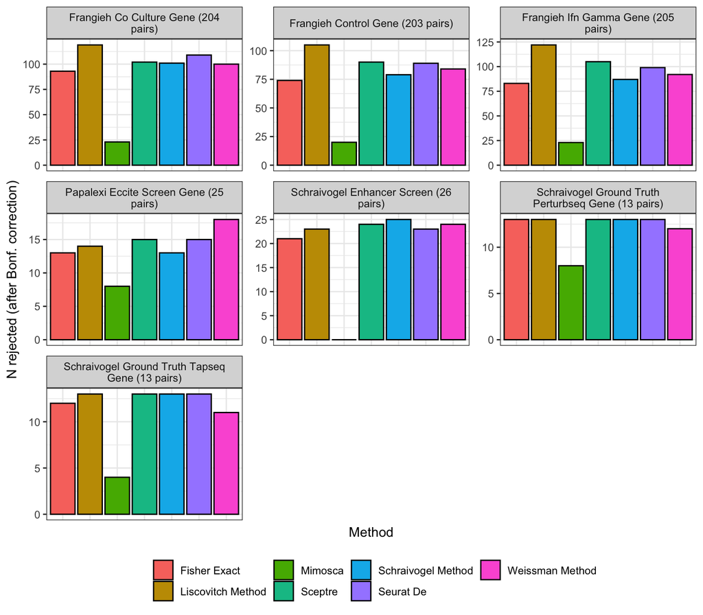

Some questions remain regarding the application of Fisher’s exact test to single-cell CRISPR screen data (for example, how should the contingency table be constructed for highly expressed features)? Nonetheless, if I had to advise a biologist tomorrow about what method he should use to analyze his single-cell CRISPR screen data, I would recommend Fisher’s exact test.